# Risk Factor Analysis

## Outcome Variable

**Outcome Variable:** pers_wast

## Predictor Variables

**Intervention Variable:** parity

**Adjustment Set:**

- arm
- W_mage
- meducyrs
- feducyrs
- hhwealth_quart
- W_mhtcm
- W_mwtkg
- W_mbmi
- vagbrth
- impsan
- delta_W_mage
- delta_meducyrs
- delta_feducyrs
- delta_hhwealth_quart
- delta_W_mhtcm
- delta_W_mwtkg
- delta_W_mbmi
- delta_vagbrth
- delta_impsan

## Stratifying Variables

The analysis was stratified on these variable(s):

- agecat
- studyid
- country

## Data Summary

| agecat | studyid | country | parity | pers_wast | n_cell | n |
| --- | --- | --- | --- | --- | --- | --- |
| 0-24 months | ki1000304b-SAS-CompFeed | INDIA | 1 | 0 | 378 | 1366 |
| 0-24 months | ki1000304b-SAS-CompFeed | INDIA | 1 | 1 | 30 | 1366 |
| 0-24 months | ki1000304b-SAS-CompFeed | INDIA | 2 | 0 | 291 | 1366 |
| 0-24 months | ki1000304b-SAS-CompFeed | INDIA | 2 | 1 | 27 | 1366 |
| 0-24 months | ki1000304b-SAS-CompFeed | INDIA | 3+ | 0 | 583 | 1366 |
| 0-24 months | ki1000304b-SAS-CompFeed | INDIA | 3+ | 1 | 57 | 1366 |
| 0-24 months | ki1000304b-SAS-FoodSuppl | INDIA | 1 | 0 | 1 | 375 |
| 0-24 months | ki1000304b-SAS-FoodSuppl | INDIA | 1 | 1 | 1 | 375 |
| 0-24 months | ki1000304b-SAS-FoodSuppl | INDIA | 2 | 0 | 62 | 375 |
| 0-24 months | ki1000304b-SAS-FoodSuppl | INDIA | 2 | 1 | 7 | 375 |
| 0-24 months | ki1000304b-SAS-FoodSuppl | INDIA | 3+ | 0 | 247 | 375 |
| 0-24 months | ki1000304b-SAS-FoodSuppl | INDIA | 3+ | 1 | 57 | 375 |
| 0-24 months | ki1017093b-PROVIDE | BANGLADESH | 1 | 0 | 238 | 641 |
| 0-24 months | ki1017093b-PROVIDE | BANGLADESH | 1 | 1 | 4 | 641 |
| 0-24 months | ki1017093b-PROVIDE | BANGLADESH | 2 | 0 | 223 | 641 |
| 0-24 months | ki1017093b-PROVIDE | BANGLADESH | 2 | 1 | 4 | 641 |
| 0-24 months | ki1017093b-PROVIDE | BANGLADESH | 3+ | 0 | 165 | 641 |
| 0-24 months | ki1017093b-PROVIDE | BANGLADESH | 3+ | 1 | 7 | 641 |
| 0-24 months | ki1066203-TanzaniaChild2 | TANZANIA, UNITED REPUBLIC OF | 1 | 0 | 710 | 2132 |
| 0-24 months | ki1066203-TanzaniaChild2 | TANZANIA, UNITED REPUBLIC OF | 1 | 1 | 18 | 2132 |
| 0-24 months | ki1066203-TanzaniaChild2 | TANZANIA, UNITED REPUBLIC OF | 2 | 0 | 683 | 2132 |
| 0-24 months | ki1066203-TanzaniaChild2 | TANZANIA, UNITED REPUBLIC OF | 2 | 1 | 20 | 2132 |
| 0-24 months | ki1066203-TanzaniaChild2 | TANZANIA, UNITED REPUBLIC OF | 3+ | 0 | 682 | 2132 |
| 0-24 months | ki1066203-TanzaniaChild2 | TANZANIA, UNITED REPUBLIC OF | 3+ | 1 | 19 | 2132 |
| 0-24 months | ki1101329-Keneba | GAMBIA | 1 | 0 | 218 | 1853 |
| 0-24 months | ki1101329-Keneba | GAMBIA | 1 | 1 | 11 | 1853 |
| 0-24 months | ki1101329-Keneba | GAMBIA | 2 | 0 | 190 | 1853 |
| 0-24 months | ki1101329-Keneba | GAMBIA | 2 | 1 | 10 | 1853 |
| 0-24 months | ki1101329-Keneba | GAMBIA | 3+ | 0 | 1342 | 1853 |
| 0-24 months | ki1101329-Keneba | GAMBIA | 3+ | 1 | 82 | 1853 |

[output cut: 144 more lines]

The following strata were considered:

- agecat: 0-24 months, studyid: ki1000304b-SAS-CompFeed, country: INDIA
- agecat: 0-24 months, studyid: ki1000304b-SAS-FoodSuppl, country: INDIA
- agecat: 0-24 months, studyid: ki1017093b-PROVIDE, country: BANGLADESH
- agecat: 0-24 months, studyid: ki1066203-TanzaniaChild2, country: TANZANIA, UNITED REPUBLIC OF
- agecat: 0-24 months, studyid: ki1101329-Keneba, country: GAMBIA
- agecat: 0-24 months, studyid: ki1113344-GMS-Nepal, country: NEPAL
- agecat: 0-24 months, studyid: ki1126311-ZVITAMBO, country: ZIMBABWE
- agecat: 0-24 months, studyid: ki1135781-COHORTS, country: GUATEMALA
- agecat: 0-24 months, studyid: ki1135781-COHORTS, country: INDIA
- agecat: 0-24 months, studyid: ki1135781-COHORTS, country: PHILIPPINES
- agecat: 0-24 months, studyid: kiGH5241-JiVitA-3, country: BANGLADESH
- agecat: 0-6 months, studyid: ki1017093b-PROVIDE, country: BANGLADESH
- agecat: 0-6 months, studyid: ki1066203-TanzaniaChild2, country: TANZANIA, UNITED REPUBLIC OF
- agecat: 0-6 months, studyid: ki1101329-Keneba, country: GAMBIA
- agecat: 0-6 months, studyid: ki1113344-GMS-Nepal, country: NEPAL
- agecat: 0-6 months, studyid: ki1126311-ZVITAMBO, country: ZIMBABWE
- agecat: 0-6 months, studyid: ki1135781-COHORTS, country: PHILIPPINES
- agecat: 0-6 months, studyid: kiGH5241-JiVitA-3, country: BANGLADESH
- agecat: 6-24 months, studyid: ki1000304b-SAS-CompFeed, country: INDIA
- agecat: 6-24 months, studyid: ki1000304b-SAS-FoodSuppl, country: INDIA
- agecat: 6-24 months, studyid: ki1017093b-PROVIDE, country: BANGLADESH
- agecat: 6-24 months, studyid: ki1066203-TanzaniaChild2, country: TANZANIA, UNITED REPUBLIC OF
- agecat: 6-24 months, studyid: ki1101329-Keneba, country: GAMBIA
- agecat: 6-24 months, studyid: ki1113344-GMS-Nepal, country: NEPAL
- agecat: 6-24 months, studyid: ki1126311-ZVITAMBO, country: ZIMBABWE
- agecat: 6-24 months, studyid: ki1135781-COHORTS, country: GUATEMALA
- agecat: 6-24 months, studyid: ki1135781-COHORTS, country: INDIA
- agecat: 6-24 months, studyid: ki1135781-COHORTS, country: PHILIPPINES
- agecat: 6-24 months, studyid: kiGH5241-JiVitA-3, country: BANGLADESH

### Dropped Strata

Some strata were dropped due to rare outcomes:

- agecat: 0-24 months, studyid: ki1000304b-SAS-FoodSuppl, country: INDIA
- agecat: 0-24 months, studyid: ki1017093b-PROVIDE, country: BANGLADESH
- agecat: 0-24 months, studyid: ki1135781-COHORTS, country: GUATEMALA
- agecat: 0-6 months, studyid: ki1017093b-PROVIDE, country: BANGLADESH
- agecat: 0-6 months, studyid: ki1101329-Keneba, country: GAMBIA
- agecat: 0-6 months, studyid: ki1126311-ZVITAMBO, country: ZIMBABWE
- agecat: 0-6 months, studyid: kiGH5241-JiVitA-3, country: BANGLADESH
- agecat: 6-24 months, studyid: ki1000304b-SAS-FoodSuppl, country: INDIA
- agecat: 6-24 months, studyid: ki1017093b-PROVIDE, country: BANGLADESH
- agecat: 6-24 months, studyid: ki1135781-COHORTS, country: GUATEMALA

## Methods Detail

We’re interested in the causal parameters $E[Y_a]$ for all values of $a \in \mathcal{A}$. These parameters represent the mean outcome if, possibly contrary to fact, we intervened to set all units to have $A=a$. Under the randomization and positivity assumptions, these are identified by the statistical parameters $\psi_a=E_W[E_{Y|A,W}(Y|A=a,W)]$. In addition, we’re interested in the mean of $Y$, $E[Y]$ under no intervention (the observed mean). We will estimate these parameters by using SuperLearner to fit the relevant likelihood factors – $E_{Y|A,W}(Y|A=a,W)$ and $p(A=a|W)$, and then updating our likelihood fit using a joint TMLE.

For unadjusted analyses ($W=\{\}$), initial likelihoods were estimated using Lrnr_glm to estimate the simple $E(Y|A)$ and Lrnr_mean to estimate $p(A)$. For adjusted analyses, a small library containing Lrnr_glmnet, Lrnr_xgboost, and Lrnr_mean was used.

Having estimated these parameters, we will then use the delta method to estimate relative risks and attributable risks relative to a prespecified baseline level of $A$.

# Results Detail

## Results Plots

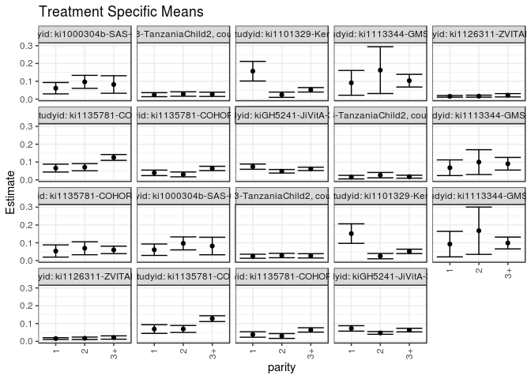

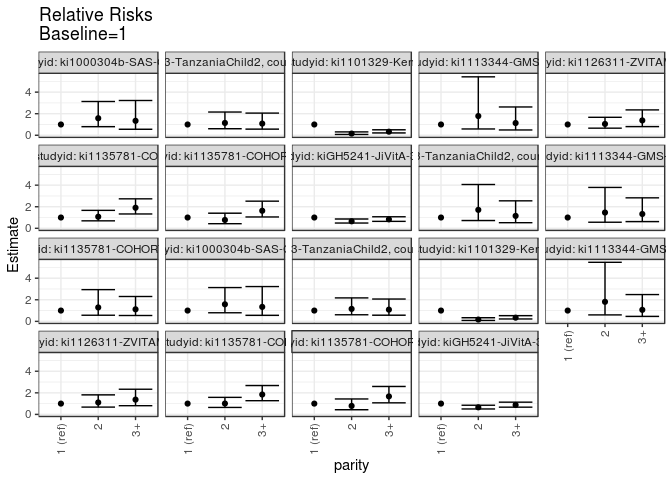

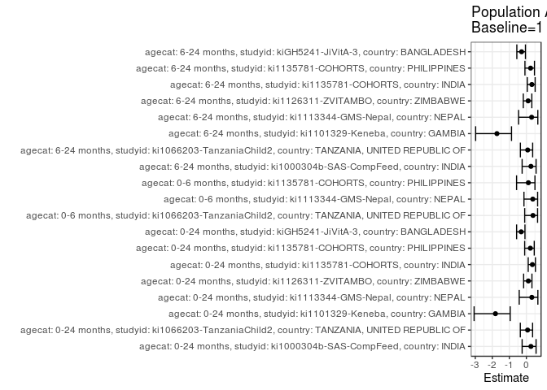

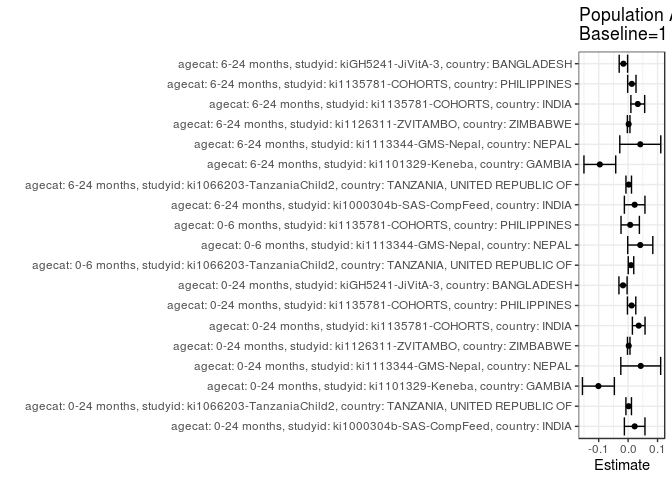

## Results Table

### Parameter: TSM

| agecat | studyid | country | intervention_level | baseline_level | estimate | ci_lower | ci_upper |
| --- | --- | --- | --- | --- | --- | --- | --- |
| 0-24 months | ki1000304b-SAS-CompFeed | INDIA | 1 | NA | 0.0612154 | 0.0292447 | 0.0931861 |
| 0-24 months | ki1000304b-SAS-CompFeed | INDIA | 2 | NA | 0.0967276 | 0.0603010 | 0.1331541 |
| 0-24 months | ki1000304b-SAS-CompFeed | INDIA | 3+ | NA | 0.0820545 | 0.0328692 | 0.1312398 |
| 0-24 months | ki1066203-TanzaniaChild2 | TANZANIA, UNITED REPUBLIC OF | 1 | NA | 0.0248032 | 0.0134296 | 0.0361768 |
| 0-24 months | ki1066203-TanzaniaChild2 | TANZANIA, UNITED REPUBLIC OF | 2 | NA | 0.0283693 | 0.0159803 | 0.0407584 |
| 0-24 months | ki1066203-TanzaniaChild2 | TANZANIA, UNITED REPUBLIC OF | 3+ | NA | 0.0268639 | 0.0148058 | 0.0389219 |
| 0-24 months | ki1101329-Keneba | GAMBIA | 1 | NA | 0.1565650 | 0.1014357 | 0.2116943 |
| 0-24 months | ki1101329-Keneba | GAMBIA | 2 | NA | 0.0244633 | 0.0096997 | 0.0392268 |
| 0-24 months | ki1101329-Keneba | GAMBIA | 3+ | NA | 0.0520695 | 0.0396159 | 0.0645231 |
| 0-24 months | ki1113344-GMS-Nepal | NEPAL | 1 | NA | 0.0911386 | 0.0216073 | 0.1606699 |
| 0-24 months | ki1113344-GMS-Nepal | NEPAL | 2 | NA | 0.1625098 | 0.0311648 | 0.2938548 |
| 0-24 months | ki1113344-GMS-Nepal | NEPAL | 3+ | NA | 0.1033944 | 0.0678023 | 0.1389865 |
| 0-24 months | ki1126311-ZVITAMBO | ZIMBABWE | 1 | NA | 0.0155902 | 0.0107452 | 0.0204352 |
| 0-24 months | ki1126311-ZVITAMBO | ZIMBABWE | 2 | NA | 0.0163668 | 0.0107614 | 0.0219722 |
| 0-24 months | ki1126311-ZVITAMBO | ZIMBABWE | 3+ | NA | 0.0214515 | 0.0120812 | 0.0308218 |
| 0-24 months | ki1135781-COHORTS | INDIA | 1 | NA | 0.0660866 | 0.0439050 | 0.0882683 |
| 0-24 months | ki1135781-COHORTS | INDIA | 2 | NA | 0.0709171 | 0.0510007 | 0.0908334 |
| 0-24 months | ki1135781-COHORTS | INDIA | 3+ | NA | 0.1259379 | 0.1095853 | 0.1422905 |
| 0-24 months | ki1135781-COHORTS | PHILIPPINES | 1 | NA | 0.0393720 | 0.0239302 | 0.0548138 |
| 0-24 months | ki1135781-COHORTS | PHILIPPINES | 2 | NA | 0.0304997 | 0.0169616 | 0.0440378 |
| 0-24 months | ki1135781-COHORTS | PHILIPPINES | 3+ | NA | 0.0640829 | 0.0519763 | 0.0761895 |
| 0-24 months | kiGH5241-JiVitA-3 | BANGLADESH | 1 | NA | 0.0741854 | 0.0594601 | 0.0889107 |
| 0-24 months | kiGH5241-JiVitA-3 | BANGLADESH | 2 | NA | 0.0481869 | 0.0381565 | 0.0582173 |
| 0-24 months | kiGH5241-JiVitA-3 | BANGLADESH | 3+ | NA | 0.0616368 | 0.0522955 | 0.0709781 |
| 0-6 months | ki1066203-TanzaniaChild2 | TANZANIA, UNITED REPUBLIC OF | 1 | NA | 0.0153966 | 0.0054772 | 0.0253160 |
| 0-6 months | ki1066203-TanzaniaChild2 | TANZANIA, UNITED REPUBLIC OF | 2 | NA | 0.0263536 | 0.0111915 | 0.0415158 |
| 0-6 months | ki1066203-TanzaniaChild2 | TANZANIA, UNITED REPUBLIC OF | 3+ | NA | 0.0177271 | 0.0095113 | 0.0259429 |
| 0-6 months | ki1113344-GMS-Nepal | NEPAL | 1 | NA | 0.0680972 | 0.0241174 | 0.1120770 |
| 0-6 months | ki1113344-GMS-Nepal | NEPAL | 2 | NA | 0.0996008 | 0.0299810 | 0.1692207 |
| 0-6 months | ki1113344-GMS-Nepal | NEPAL | 3+ | NA | 0.0903797 | 0.0549919 | 0.1257674 |
| 0-6 months | ki1135781-COHORTS | PHILIPPINES | 1 | NA | 0.0538922 | 0.0196251 | 0.0881594 |
| 0-6 months | ki1135781-COHORTS | PHILIPPINES | 2 | NA | 0.0695187 | 0.0330444 | 0.1059930 |
| 0-6 months | ki1135781-COHORTS | PHILIPPINES | 3+ | NA | 0.0601202 | 0.0392514 | 0.0809891 |
| 6-24 months | ki1000304b-SAS-CompFeed | INDIA | 1 | NA | 0.0612154 | 0.0292447 | 0.0931861 |
| 6-24 months | ki1000304b-SAS-CompFeed | INDIA | 2 | NA | 0.0967276 | 0.0603010 | 0.1331541 |
| 6-24 months | ki1000304b-SAS-CompFeed | INDIA | 3+ | NA | 0.0820545 | 0.0328692 | 0.1312398 |
| 6-24 months | ki1066203-TanzaniaChild2 | TANZANIA, UNITED REPUBLIC OF | 1 | NA | 0.0246790 | 0.0133050 | 0.0360530 |
| 6-24 months | ki1066203-TanzaniaChild2 | TANZANIA, UNITED REPUBLIC OF | 2 | NA | 0.0284869 | 0.0160921 | 0.0408816 |
| 6-24 months | ki1066203-TanzaniaChild2 | TANZANIA, UNITED REPUBLIC OF | 3+ | NA | 0.0268198 | 0.0147772 | 0.0388623 |
| 6-24 months | ki1101329-Keneba | GAMBIA | 1 | NA | 0.1517109 | 0.0968621 | 0.2065598 |
| 6-24 months | ki1101329-Keneba | GAMBIA | 2 | NA | 0.0253713 | 0.0103472 | 0.0403955 |
| 6-24 months | ki1101329-Keneba | GAMBIA | 3+ | NA | 0.0519079 | 0.0396888 | 0.0641270 |
| 6-24 months | ki1113344-GMS-Nepal | NEPAL | 1 | NA | 0.0926810 | 0.0210448 | 0.1643172 |
| 6-24 months | ki1113344-GMS-Nepal | NEPAL | 2 | NA | 0.1679105 | 0.0350601 | 0.3007609 |
| 6-24 months | ki1113344-GMS-Nepal | NEPAL | 3+ | NA | 0.0989110 | 0.0656825 | 0.1321396 |
| 6-24 months | ki1126311-ZVITAMBO | ZIMBABWE | 1 | NA | 0.0158145 | 0.0108572 | 0.0207718 |
| 6-24 months | ki1126311-ZVITAMBO | ZIMBABWE | 2 | NA | 0.0174787 | 0.0108159 | 0.0241415 |
| 6-24 months | ki1126311-ZVITAMBO | ZIMBABWE | 3+ | NA | 0.0216475 | 0.0123418 | 0.0309531 |
| 6-24 months | ki1135781-COHORTS | INDIA | 1 | NA | 0.0692628 | 0.0450439 | 0.0934817 |
| 6-24 months | ki1135781-COHORTS | INDIA | 2 | NA | 0.0698000 | 0.0503314 | 0.0892685 |
| 6-24 months | ki1135781-COHORTS | INDIA | 3+ | NA | 0.1276709 | 0.1114103 | 0.1439315 |
| 6-24 months | ki1135781-COHORTS | PHILIPPINES | 1 | NA | 0.0386238 | 0.0232601 | 0.0539875 |
| 6-24 months | ki1135781-COHORTS | PHILIPPINES | 2 | NA | 0.0303333 | 0.0167344 | 0.0439322 |
| 6-24 months | ki1135781-COHORTS | PHILIPPINES | 3+ | NA | 0.0643626 | 0.0521513 | 0.0765738 |
| 6-24 months | kiGH5241-JiVitA-3 | BANGLADESH | 1 | NA | 0.0728612 | 0.0576939 | 0.0880285 |
| 6-24 months | kiGH5241-JiVitA-3 | BANGLADESH | 2 | NA | 0.0476252 | 0.0399414 | 0.0553089 |
| 6-24 months | kiGH5241-JiVitA-3 | BANGLADESH | 3+ | NA | 0.0634380 | 0.0534635 | 0.0734125 |

### Parameter: E(Y)

| agecat | studyid | country | intervention_level | baseline_level | estimate | ci_lower | ci_upper |
| --- | --- | --- | --- | --- | --- | --- | --- |
| 0-24 months | ki1000304b-SAS-CompFeed | INDIA | NA | NA | 0.0834553 | 0.0601989 | 0.1067118 |
| 0-24 months | ki1066203-TanzaniaChild2 | TANZANIA, UNITED REPUBLIC OF | NA | NA | 0.0267355 | 0.0198866 | 0.0335843 |
| 0-24 months | ki1101329-Keneba | GAMBIA | NA | NA | 0.0555855 | 0.0451506 | 0.0660205 |
| 0-24 months | ki1113344-GMS-Nepal | NEPAL | NA | NA | 0.1340034 | 0.1066544 | 0.1613523 |
| 0-24 months | ki1126311-ZVITAMBO | ZIMBABWE | NA | NA | 0.0176359 | 0.0149926 | 0.0202793 |
| 0-24 months | ki1135781-COHORTS | INDIA | NA | NA | 0.1020862 | 0.0921879 | 0.1119845 |
| 0-24 months | ki1135781-COHORTS | PHILIPPINES | NA | NA | 0.0512273 | 0.0430760 | 0.0593786 |
| 0-24 months | kiGH5241-JiVitA-3 | BANGLADESH | NA | NA | 0.0568247 | 0.0527145 | 0.0609348 |
| 0-6 months | ki1066203-TanzaniaChild2 | TANZANIA, UNITED REPUBLIC OF | NA | NA | 0.0251232 | 0.0183136 | 0.0319327 |
| 0-6 months | ki1113344-GMS-Nepal | NEPAL | NA | NA | 0.1093474 | 0.0836377 | 0.1350572 |
| 0-6 months | ki1135781-COHORTS | PHILIPPINES | NA | NA | 0.0609613 | 0.0448957 | 0.0770269 |
| 6-24 months | ki1000304b-SAS-CompFeed | INDIA | NA | NA | 0.0834553 | 0.0601989 | 0.1067118 |
| 6-24 months | ki1066203-TanzaniaChild2 | TANZANIA, UNITED REPUBLIC OF | NA | NA | 0.0267355 | 0.0198866 | 0.0335843 |
| 6-24 months | ki1101329-Keneba | GAMBIA | NA | NA | 0.0555855 | 0.0451506 | 0.0660205 |
| 6-24 months | ki1113344-GMS-Nepal | NEPAL | NA | NA | 0.1340034 | 0.1066544 | 0.1613523 |
| 6-24 months | ki1126311-ZVITAMBO | ZIMBABWE | NA | NA | 0.0176359 | 0.0149926 | 0.0202793 |
| 6-24 months | ki1135781-COHORTS | INDIA | NA | NA | 0.1020862 | 0.0921879 | 0.1119845 |
| 6-24 months | ki1135781-COHORTS | PHILIPPINES | NA | NA | 0.0512273 | 0.0430760 | 0.0593786 |
| 6-24 months | kiGH5241-JiVitA-3 | BANGLADESH | NA | NA | 0.0568247 | 0.0527145 | 0.0609348 |

### Parameter: RR

| agecat | studyid | country | intervention_level | baseline_level | estimate | ci_lower | ci_upper |
| --- | --- | --- | --- | --- | --- | --- | --- |
| 0-24 months | ki1000304b-SAS-CompFeed | INDIA | 1 | 1 | 1.0000000 | 1.0000000 | 1.0000000 |
| 0-24 months | ki1000304b-SAS-CompFeed | INDIA | 2 | 1 | 1.5801175 | 0.7973545 | 3.1313192 |
| 0-24 months | ki1000304b-SAS-CompFeed | INDIA | 3+ | 1 | 1.3404226 | 0.5573966 | 3.2234364 |
| 0-24 months | ki1066203-TanzaniaChild2 | TANZANIA, UNITED REPUBLIC OF | 1 | 1 | 1.0000000 | 1.0000000 | 1.0000000 |
| 0-24 months | ki1066203-TanzaniaChild2 | TANZANIA, UNITED REPUBLIC OF | 2 | 1 | 1.1437771 | 0.6071403 | 2.1547343 |
| 0-24 months | ki1066203-TanzaniaChild2 | TANZANIA, UNITED REPUBLIC OF | 3+ | 1 | 1.0830803 | 0.5700629 | 2.0577779 |
| 0-24 months | ki1101329-Keneba | GAMBIA | 1 | 1 | 1.0000000 | 1.0000000 | 1.0000000 |
| 0-24 months | ki1101329-Keneba | GAMBIA | 2 | 1 | 0.1562500 | 0.0775635 | 0.3147622 |
| 0-24 months | ki1101329-Keneba | GAMBIA | 3+ | 1 | 0.3325743 | 0.2174397 | 0.5086729 |
| 0-24 months | ki1113344-GMS-Nepal | NEPAL | 1 | 1 | 1.0000000 | 1.0000000 | 1.0000000 |
| 0-24 months | ki1113344-GMS-Nepal | NEPAL | 2 | 1 | 1.7831061 | 0.5867062 | 5.4191813 |
| 0-24 months | ki1113344-GMS-Nepal | NEPAL | 3+ | 1 | 1.1344743 | 0.4903226 | 2.6248673 |
| 0-24 months | ki1126311-ZVITAMBO | ZIMBABWE | 1 | 1 | 1.0000000 | 1.0000000 | 1.0000000 |
| 0-24 months | ki1126311-ZVITAMBO | ZIMBABWE | 2 | 1 | 1.0498134 | 0.6612229 | 1.6667726 |
| 0-24 months | ki1126311-ZVITAMBO | ZIMBABWE | 3+ | 1 | 1.3759580 | 0.8049907 | 2.3519034 |
| 0-24 months | ki1135781-COHORTS | INDIA | 1 | 1 | 1.0000000 | 1.0000000 | 1.0000000 |
| 0-24 months | ki1135781-COHORTS | INDIA | 2 | 1 | 1.0730924 | 0.6928975 | 1.6619013 |
| 0-24 months | ki1135781-COHORTS | INDIA | 3+ | 1 | 1.9056482 | 1.3298410 | 2.7307739 |
| 0-24 months | ki1135781-COHORTS | PHILIPPINES | 1 | 1 | 1.0000000 | 1.0000000 | 1.0000000 |
| 0-24 months | ki1135781-COHORTS | PHILIPPINES | 2 | 1 | 0.7746549 | 0.4284313 | 1.4006683 |
| 0-24 months | ki1135781-COHORTS | PHILIPPINES | 3+ | 1 | 1.6276272 | 1.0531394 | 2.5154982 |
| 0-24 months | kiGH5241-JiVitA-3 | BANGLADESH | 1 | 1 | 1.0000000 | 1.0000000 | 1.0000000 |
| 0-24 months | kiGH5241-JiVitA-3 | BANGLADESH | 2 | 1 | 0.6495472 | 0.4884029 | 0.8638596 |
| 0-24 months | kiGH5241-JiVitA-3 | BANGLADESH | 3+ | 1 | 0.8308485 | 0.6449576 | 1.0703173 |
| 0-6 months | ki1066203-TanzaniaChild2 | TANZANIA, UNITED REPUBLIC OF | 1 | 1 | 1.0000000 | 1.0000000 | 1.0000000 |
| 0-6 months | ki1066203-TanzaniaChild2 | TANZANIA, UNITED REPUBLIC OF | 2 | 1 | 1.7116577 | 0.7211600 | 4.0625827 |
| 0-6 months | ki1066203-TanzaniaChild2 | TANZANIA, UNITED REPUBLIC OF | 3+ | 1 | 1.1513677 | 0.5200072 | 2.5492874 |
| 0-6 months | ki1113344-GMS-Nepal | NEPAL | 1 | 1 | 1.0000000 | 1.0000000 | 1.0000000 |
| 0-6 months | ki1113344-GMS-Nepal | NEPAL | 2 | 1 | 1.4626280 | 0.5642979 | 3.7910482 |
| 0-6 months | ki1113344-GMS-Nepal | NEPAL | 3+ | 1 | 1.3272159 | 0.6230652 | 2.8271552 |
| 0-6 months | ki1135781-COHORTS | PHILIPPINES | 1 | 1 | 1.0000000 | 1.0000000 | 1.0000000 |
| 0-6 months | ki1135781-COHORTS | PHILIPPINES | 2 | 1 | 1.2899584 | 0.5656642 | 2.9416615 |
| 0-6 months | ki1135781-COHORTS | PHILIPPINES | 3+ | 1 | 1.1155645 | 0.5406060 | 2.3020166 |
| 6-24 months | ki1000304b-SAS-CompFeed | INDIA | 1 | 1 | 1.0000000 | 1.0000000 | 1.0000000 |
| 6-24 months | ki1000304b-SAS-CompFeed | INDIA | 2 | 1 | 1.5801175 | 0.7973545 | 3.1313192 |
| 6-24 months | ki1000304b-SAS-CompFeed | INDIA | 3+ | 1 | 1.3404226 | 0.5573966 | 3.2234364 |
| 6-24 months | ki1066203-TanzaniaChild2 | TANZANIA, UNITED REPUBLIC OF | 1 | 1 | 1.0000000 | 1.0000000 | 1.0000000 |
| 6-24 months | ki1066203-TanzaniaChild2 | TANZANIA, UNITED REPUBLIC OF | 2 | 1 | 1.1542973 | 0.6123997 | 2.1757067 |
| 6-24 months | ki1066203-TanzaniaChild2 | TANZANIA, UNITED REPUBLIC OF | 3+ | 1 | 1.0867456 | 0.5710143 | 2.0682776 |
| 6-24 months | ki1101329-Keneba | GAMBIA | 1 | 1 | 1.0000000 | 1.0000000 | 1.0000000 |
| 6-24 months | ki1101329-Keneba | GAMBIA | 2 | 1 | 0.1672347 | 0.0834328 | 0.3352092 |
| 6-24 months | ki1101329-Keneba | GAMBIA | 3+ | 1 | 0.3421500 | 0.2224098 | 0.5263556 |
| 6-24 months | ki1113344-GMS-Nepal | NEPAL | 1 | 1 | 1.0000000 | 1.0000000 | 1.0000000 |
| 6-24 months | ki1113344-GMS-Nepal | NEPAL | 2 | 1 | 1.8117032 | 0.5995941 | 5.4741507 |
| 6-24 months | ki1113344-GMS-Nepal | NEPAL | 3+ | 1 | 1.0672201 | 0.4586188 | 2.4834542 |
| 6-24 months | ki1126311-ZVITAMBO | ZIMBABWE | 1 | 1 | 1.0000000 | 1.0000000 | 1.0000000 |
| 6-24 months | ki1126311-ZVITAMBO | ZIMBABWE | 2 | 1 | 1.1052300 | 0.6748147 | 1.8101759 |
| 6-24 months | ki1126311-ZVITAMBO | ZIMBABWE | 3+ | 1 | 1.3688352 | 0.8040970 | 2.3302037 |
| 6-24 months | ki1135781-COHORTS | INDIA | 1 | 1 | 1.0000000 | 1.0000000 | 1.0000000 |
| 6-24 months | ki1135781-COHORTS | INDIA | 2 | 1 | 1.0077560 | 0.6443085 | 1.5762205 |
| 6-24 months | ki1135781-COHORTS | INDIA | 3+ | 1 | 1.8432832 | 1.2706608 | 2.6739575 |
| 6-24 months | ki1135781-COHORTS | PHILIPPINES | 1 | 1 | 1.0000000 | 1.0000000 | 1.0000000 |
| 6-24 months | ki1135781-COHORTS | PHILIPPINES | 2 | 1 | 0.7853536 | 0.4313029 | 1.4300398 |
| 6-24 months | ki1135781-COHORTS | PHILIPPINES | 3+ | 1 | 1.6663979 | 1.0723914 | 2.5894296 |
| 6-24 months | kiGH5241-JiVitA-3 | BANGLADESH | 1 | 1 | 1.0000000 | 1.0000000 | 1.0000000 |
| 6-24 months | kiGH5241-JiVitA-3 | BANGLADESH | 2 | 1 | 0.6536423 | 0.5033825 | 0.8487549 |
| 6-24 months | kiGH5241-JiVitA-3 | BANGLADESH | 3+ | 1 | 0.8706691 | 0.6680069 | 1.1348158 |

### Parameter: PAR

| agecat | studyid | country | intervention_level | baseline_level | estimate | ci_lower | ci_upper |
| --- | --- | --- | --- | --- | --- | --- | --- |
| 0-24 months | ki1000304b-SAS-CompFeed | INDIA | 1 | NA | 0.0222399 | -0.0127241 | 0.0572040 |
| 0-24 months | ki1066203-TanzaniaChild2 | TANZANIA, UNITED REPUBLIC OF | 1 | NA | 0.0019322 | -0.0074898 | 0.0113543 |
| 0-24 months | ki1101329-Keneba | GAMBIA | 1 | NA | -0.1009795 | -0.1552000 | -0.0467590 |
| 0-24 months | ki1113344-GMS-Nepal | NEPAL | 1 | NA | 0.0428647 | -0.0248484 | 0.1105779 |
| 0-24 months | ki1126311-ZVITAMBO | ZIMBABWE | 1 | NA | 0.0020457 | -0.0022095 | 0.0063010 |
| 0-24 months | ki1135781-COHORTS | INDIA | 1 | NA | 0.0359996 | 0.0145259 | 0.0574733 |
| 0-24 months | ki1135781-COHORTS | PHILIPPINES | 1 | NA | 0.0118553 | -0.0023442 | 0.0260549 |
| 0-24 months | kiGH5241-JiVitA-3 | BANGLADESH | 1 | NA | -0.0173607 | -0.0312346 | -0.0034868 |
| 0-6 months | ki1066203-TanzaniaChild2 | TANZANIA, UNITED REPUBLIC OF | 1 | NA | 0.0097266 | 0.0003824 | 0.0190708 |
| 0-6 months | ki1113344-GMS-Nepal | NEPAL | 1 | NA | 0.0412503 | -0.0014093 | 0.0839099 |
| 0-6 months | ki1135781-COHORTS | PHILIPPINES | 1 | NA | 0.0070691 | -0.0241168 | 0.0382550 |
| 6-24 months | ki1000304b-SAS-CompFeed | INDIA | 1 | NA | 0.0222399 | -0.0127241 | 0.0572040 |
| 6-24 months | ki1066203-TanzaniaChild2 | TANZANIA, UNITED REPUBLIC OF | 1 | NA | 0.0020565 | -0.0073654 | 0.0114784 |
| 6-24 months | ki1101329-Keneba | GAMBIA | 1 | NA | -0.0961254 | -0.1501153 | -0.0421355 |
| 6-24 months | ki1113344-GMS-Nepal | NEPAL | 1 | NA | 0.0413223 | -0.0283197 | 0.1109644 |
| 6-24 months | ki1126311-ZVITAMBO | ZIMBABWE | 1 | NA | 0.0018214 | -0.0025519 | 0.0061948 |
| 6-24 months | ki1135781-COHORTS | INDIA | 1 | NA | 0.0328234 | 0.0093890 | 0.0562579 |
| 6-24 months | ki1135781-COHORTS | PHILIPPINES | 1 | NA | 0.0126036 | -0.0015562 | 0.0267633 |
| 6-24 months | kiGH5241-JiVitA-3 | BANGLADESH | 1 | NA | -0.0160365 | -0.0303588 | -0.0017142 |

### Parameter: PAF

| agecat | studyid | country | intervention_level | baseline_level | estimate | ci_lower | ci_upper |
| --- | --- | --- | --- | --- | --- | --- | --- |
| 0-24 months | ki1000304b-SAS-CompFeed | INDIA | 1 | NA | 0.2664890 | -0.2495519 | 0.5694149 |
| 0-24 months | ki1066203-TanzaniaChild2 | TANZANIA, UNITED REPUBLIC OF | 1 | NA | 0.0722729 | -0.3558138 | 0.3651949 |
| 0-24 months | ki1101329-Keneba | GAMBIA | 1 | NA | -1.8166500 | -3.0689129 | -0.9497879 |
| 0-24 months | ki1113344-GMS-Nepal | NEPAL | 1 | NA | 0.3198782 | -0.4201151 | 0.6742759 |
| 0-24 months | ki1126311-ZVITAMBO | ZIMBABWE | 1 | NA | 0.1159988 | -0.1606014 | 0.3266784 |
| 0-24 months | ki1135781-COHORTS | INDIA | 1 | NA | 0.3526390 | 0.1077283 | 0.5303267 |
| 0-24 months | ki1135781-COHORTS | PHILIPPINES | 1 | NA | 0.2314260 | -0.0990792 | 0.4625447 |
| 0-24 months | kiGH5241-JiVitA-3 | BANGLADESH | 1 | NA | -0.3055141 | -0.5734533 | -0.0832017 |
| 0-6 months | ki1066203-TanzaniaChild2 | TANZANIA, UNITED REPUBLIC OF | 1 | NA | 0.3871563 | -0.0979691 | 0.6579345 |
| 0-6 months | ki1113344-GMS-Nepal | NEPAL | 1 | NA | 0.3772403 | -0.1425352 | 0.6605535 |
| 0-6 months | ki1135781-COHORTS | PHILIPPINES | 1 | NA | 0.1159604 | -0.5753898 | 0.5039158 |
| 6-24 months | ki1000304b-SAS-CompFeed | INDIA | 1 | NA | 0.2664890 | -0.2495519 | 0.5694149 |
| 6-24 months | ki1066203-TanzaniaChild2 | TANZANIA, UNITED REPUBLIC OF | 1 | NA | 0.0769203 | -0.3516050 | 0.3695819 |
| 6-24 months | ki1101329-Keneba | GAMBIA | 1 | NA | -1.7293241 | -2.9781544 | -0.8725292 |
| 6-24 months | ki1113344-GMS-Nepal | NEPAL | 1 | NA | 0.3083680 | -0.4580011 | 0.6719105 |
| 6-24 months | ki1126311-ZVITAMBO | ZIMBABWE | 1 | NA | 0.1032799 | -0.1816602 | 0.3195108 |
| 6-24 months | ki1135781-COHORTS | INDIA | 1 | NA | 0.3215267 | 0.0511105 | 0.5148792 |
| 6-24 months | ki1135781-COHORTS | PHILIPPINES | 1 | NA | 0.2460319 | -0.0842776 | 0.4757173 |
| 6-24 months | kiGH5241-JiVitA-3 | BANGLADESH | 1 | NA | -0.2822106 | -0.5600438 | -0.0538576 |